# Problem 1

### 1. Creating signals

```python
class pwld_interp1d:
    def __init__(self, x, y, sigma=1.):
        n = len(x)
        dy = np.random.normal(0, sigma, n)
        self.y = np.stack([y + dy, y]).flatten('F')
        self.x = np.stack([x, x]).flatten('F')
        self.interp = interp1d(self.x, self.y, kind='linear')

    def __call__(self, y):
        return self.interp(y)
```

```python
import numpy as np
import matplotlib.pyplot as plt
from scipy.interpolate import interp1d

%matplotlib inline

x1 = np.linspace(0, 150, 20)
y1 = x1**(1/2)*np.sin(x1)

x2_1 = np.linspace(0, 150, 20)
y2_1 = np.tan(x2_1)
x2 = np.stack([x2_1, x2_1]).flatten('F')
y2_d = np.random.normal(0, 0.5, len(x2_1))
y2 = np.stack([y2_1 + y2_d, y2_1]).flatten('F')

x3 = np.linspace(0, 150, 20)
y3 = x3**(1/3)*np.cos(x3)

f1 = interp1d(x1, y1, kind='linear')
y1_new = f1(x1)

f2 = interp1d(x2, y2,kind='linear')
y2_new = f2(x2)

f3 = interp1d(x3, y3, kind='quadratic')
y3_new = f3(x3)
```

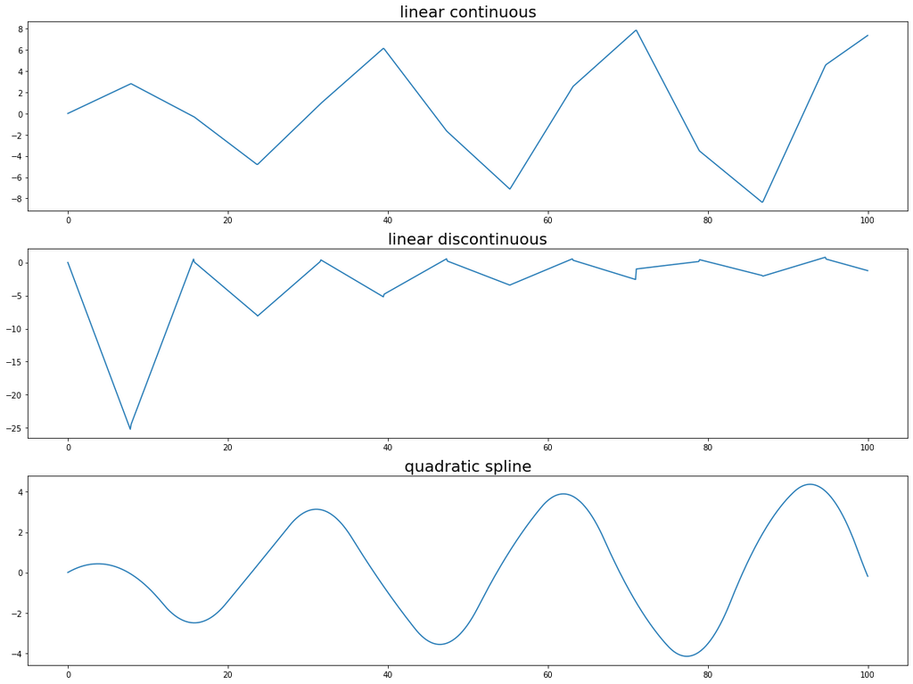

```python
fig, ax = plt.subplots(3,1, figsize=(20,15))
x_new = np.linspace(0, 100, 1000)

ax[0].set_title('linear continuous',size=20)
ax[0].plot(x_new, f1(x_new))

ax[1].set_title('linear discontinuous',size=20)
ax[1].plot(x_new, f2(x_new), '-')

ax[2].set_title('quadratic spline',size=20)
ax[2].plot(x_new, f3(x_new), '-')

plt.show()
```

### 2. Adding noise

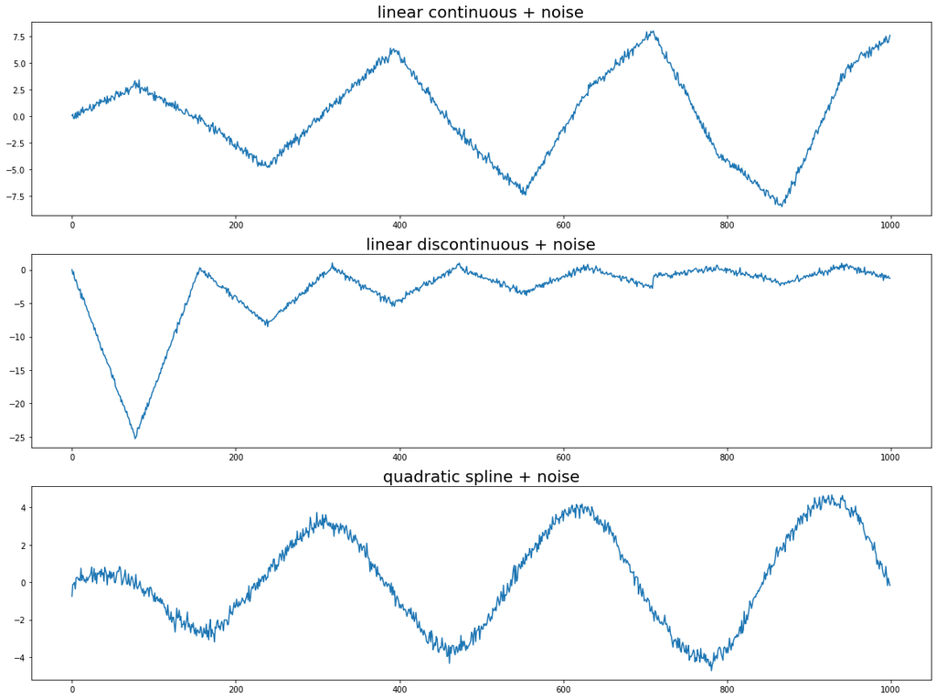

```python
fig, ax = plt.subplots(3,1, figsize=(20,15))

linear_continuous = f1(x_new) + 0.25*np.random.normal(size=x_new.shape[0])
ax[0].set_title('linear continuous + noise',size=20)
ax[0].plot(linear_continuous)


linear_discontinuous = f2(x_new) + 0.25*np.random.normal(size=x_new.shape[0])
ax[1].set_title('linear discontinuous + noise',size=20)
ax[1].plot(linear_discontinuous)

quadratic = f3(x_new) + 0.25*np.random.normal(size=x_new.shape[0])
ax[2].set_title('quadratic spline + noise',size=20)
ax[2].plot(quadratic)
plt.show()
```

### 3. Recovery procedure

```python
n = x_new.shape[0]
D1 = np.zeros((n-1,n))
i,j = np.indices(D1.shape)
D1[i==j] = 1.
D1[i==j-1] = -1.

D2 = np.zeros((n-2,n))
i,j = np.indices(D2.shape)
D2[i==j] = 1.
D2[i==j-1] = -2.
D2[i==j-2] = 1.
```

```python
import cvxpy as cp
```

##### Linear continuous signal recovery:

```python
recovery1 = cp.Variable(n)
objective= cp.norm(recovery1 - linear_continuous, p=2) + cp.norm(D1 * recovery1, p=2)
problem = cp.Problem(cp.Minimize(objective))
problem.solve()
```

```
9.021347008496525
```

```python
recovery2 = cp.Variable(n)
objective = cp.norm(recovery2 - linear_continuous, p=2) + cp.norm(D1 * recovery2, p=1)
problem = cp.Problem(cp.Minimize(objective))
problem.solve()
```

```
77.36491665730505
```

```python
recovery3 = cp.Variable(n)
objective = cp.norm(recovery3 - linear_continuous, p=2) + cp.norm(D2 * recovery3, p=1)
problem = cp.Problem(cp.Minimize(objective))
problem.solve()
```

```
8.809774775354715
```

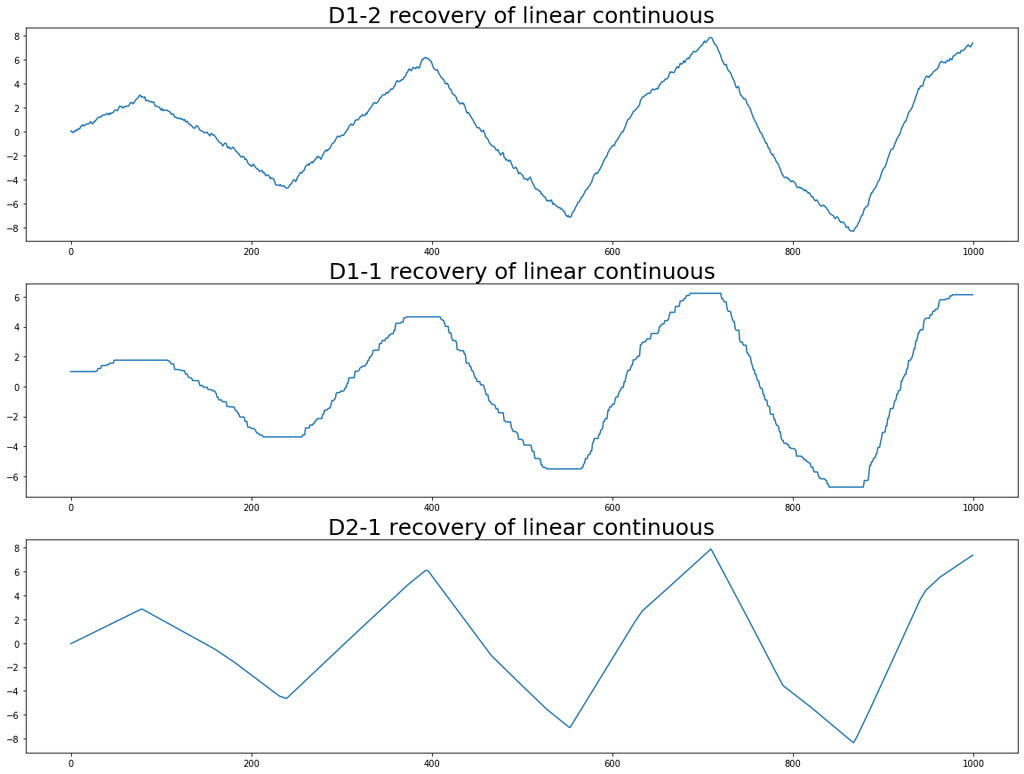

```python
fig, ax = plt.subplots(3,1, figsize=(20,15))

ax[0].set_title('D1-2 recovery of linear continuous',size=25)
ax[0].plot(recovery1.value)

ax[1].set_title('D1-1 recovery of linear continuous',size=25)
ax[1].plot(recovery2.value)

ax[2].set_title('D2-1 recovery of linear continuous',size=25)
ax[2].plot(recovery3.value)
plt.show()
```

##### Linear discontinuous signal recovery:

```python
recovery1 = cp.Variable(n)
objective= cp.norm(recovery1 - linear_discontinuous, p=2) + cp.norm(D1 * recovery1, p=2)
problem = cp.Problem(cp.Minimize(objective))
problem.solve()
```

```
10.834692211591081
```

```python
recovery2 = cp.Variable(n)
objective = cp.norm(recovery2 - linear_discontinuous, p=2) + cp.norm(D1 * recovery2, p=1)
problem = cp.Problem(cp.Minimize(objective))
problem.solve()
```

```
76.8579370136311
```

```python
recovery3 = cp.Variable(n)
objective = cp.norm(recovery3 - linear_discontinuous, p=2) + cp.norm(D2 * recovery3, p=1)
problem = cp.Problem(cp.Minimize(objective))
problem.solve()
```

```
10.665784596644713
```

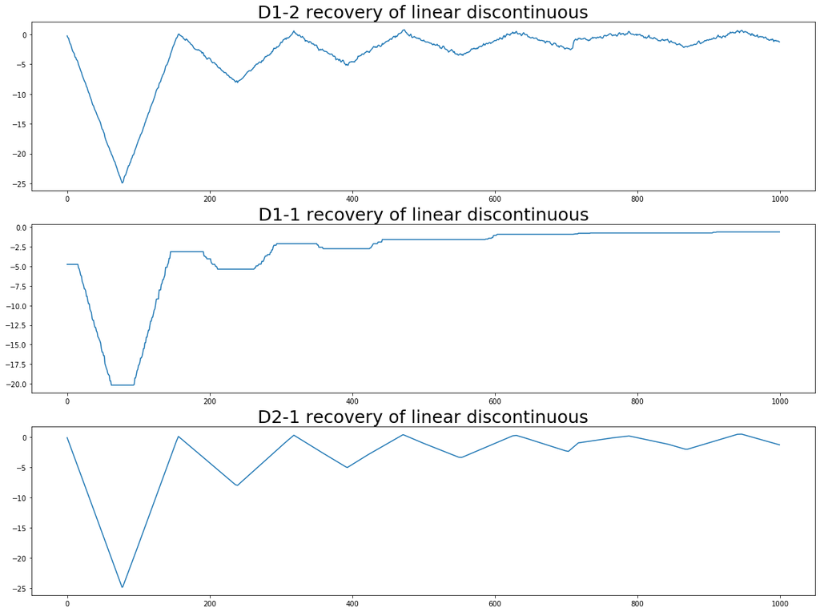

```python
fig, ax = plt.subplots(3,1, figsize=(20,15))

ax[0].set_title('D1-2 recovery of linear discontinuous',size=25)
ax[0].plot(recovery1.value)

ax[1].set_title('D1-1 recovery of linear discontinuous',size=25)
ax[1].plot(recovery2.value)

ax[2].set_title('D2-1 recovery of linear discontinuous',size=25)
ax[2].plot(recovery3.value)
plt.show()
```

##### Quadratic signal recovery:

```python
recovery1 = cp.Variable(n)
objective= cp.norm(recovery1 - quadratic, p=2) + cp.norm(D1 * recovery1, p=2)
problem = cp.Problem(cp.Minimize(objective))
problem.solve()
```

```
7.9220043398867706
```

```python
recovery2 = cp.Variable(n)
objective = cp.norm(recovery2 - quadratic, p=2) + cp.norm(D1 * recovery2, p=1)
problem = cp.Problem(cp.Minimize(objective))
problem.solve()
```

```
46.160667524476096
```

```python
recovery3 = cp.Variable(n)
objective = cp.norm(recovery3 - quadratic, p=2) + cp.norm(D2 * recovery3, p=1)
problem = cp.Problem(cp.Minimize(objective))
problem.solve()
```

```
8.148354933164654
```

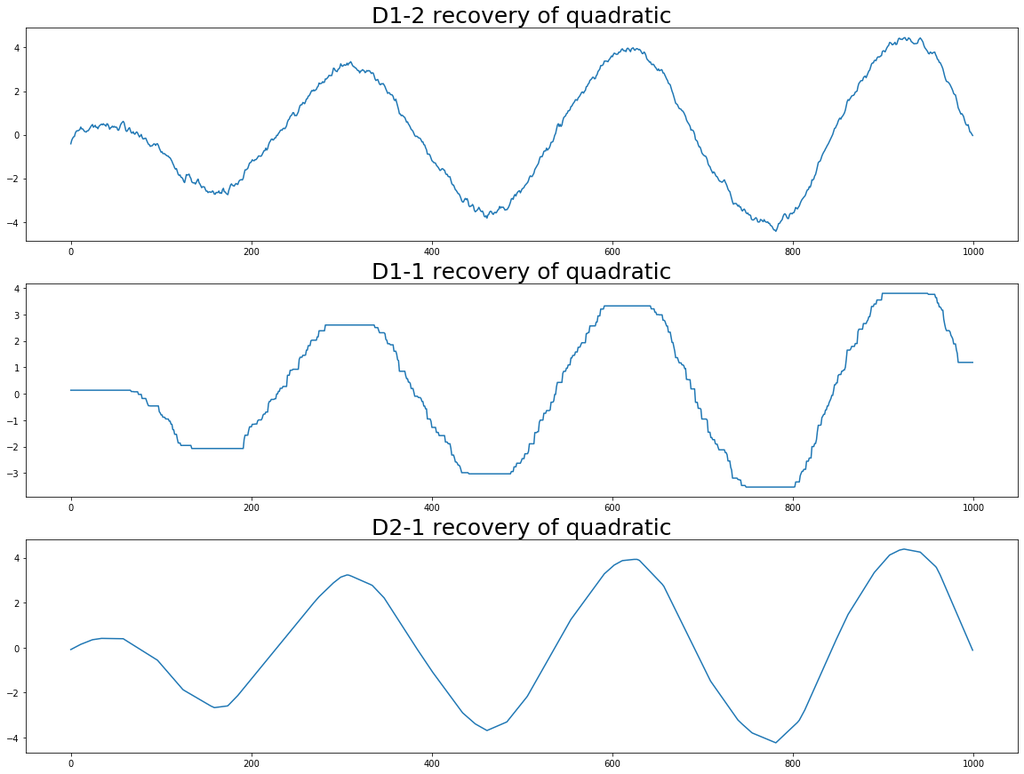

```python
fig, ax = plt.subplots(3,1, figsize=(20,15))

ax[0].set_title('D1-2 recovery of quadratic',size=25)
ax[0].plot(recovery1.value)

ax[1].set_title('D1-1 recovery of quadratic',size=25)
ax[1].plot(recovery2.value)

ax[2].set_title('D2-1 recovery of quadratic',size=25)
ax[2].plot(recovery3.value)
plt.show()
```

### 4. Dependency on the regularizer weight

##### linear continuous

```python
gammas = np.logspace(-2, 1, 20)

y = cp.Variable(1000)
res = cp.norm2(y - linear_continuous)

reg = cp.norm2(D1*y)
reg_d1_2 = []
res_d1_2 = []

for g in gammas:
    p = cp.Problem(cp.Minimize(res + g*reg))
    p.solve()
    reg_d1_2.append(reg.value)
    res_d1_2.append(res.value)

reg = cp.norm1(D1*y)
reg_d1_1 = []
res_d1_1 = []

for g in gammas:
    p = cp.Problem(cp.Minimize(res + g*reg))
    p.solve()
    reg_d1_1.append(reg.value)
    res_d1_1.append(res.value)

reg = cp.norm1(D2*y)
reg_d2_1 = []
res_d2_1 = []

for g in gammas:
    p = cp.Problem(cp.Minimize(res + g*reg))
    p.solve()
    reg_d2_1.append(reg.value)
    res_d2_1.append(res.value)
```

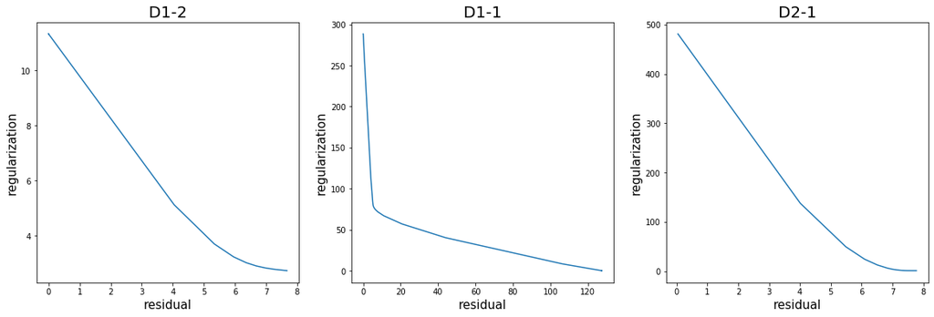

```python
_, axes = plt.subplots(1, 3, figsize=(20, 6))

axes[0].plot(res_d1_2, reg_d1_2)
axes[0].set_title('D1-2',size=20)
axes[0].set_ylabel('regularization',size=15)
axes[0].set_xlabel('residual',size=15)

axes[1].plot(res_d1_1, reg_d1_1)
axes[1].set_title('D1-1',size=20)
axes[1].set_ylabel('regularization',size=15)
axes[1].set_xlabel('residual',size=15)

axes[2].plot(res_d2_1, reg_d2_1)
axes[2].set_title('D2-1',size=20)
axes[2].set_ylabel('regularization',size=15)
axes[2].set_xlabel('residual',size=15)
plt.show()
```

##### linear discontinuous

```python
y = cp.Variable(1000)
res = cp.norm2(y - linear_discontinuous)

reg = cp.norm2(D1*y)
reg_d1_2 = []
res_d1_2 = []

for g in gammas:
    p = cp.Problem(cp.Minimize(res + g*reg))
    p.solve()
    reg_d1_2.append(reg.value)
    res_d1_2.append(res.value)

reg = cp.norm1(D1*y)
reg_d1_1 = []
res_d1_1 = []

for g in gammas:
    p = cp.Problem(cp.Minimize(res + g*reg))
    p.solve()
    reg_d1_1.append(reg.value)
    res_d1_1.append(res.value)

reg = cp.norm1(D2*y)
reg_d2_1 = []
res_d2_1 = []

for g in gammas:
    p = cp.Problem(cp.Minimize(res + g*reg))
    p.solve()
    reg_d2_1.append(reg.value)
    res_d2_1.append(res.value)
```

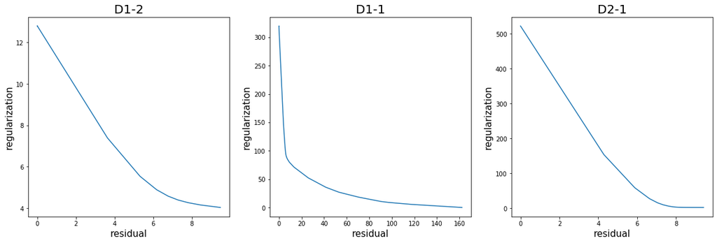

```python
_, axes = plt.subplots(1, 3, figsize=(20, 6))

axes[0].plot(res_d1_2, reg_d1_2)
axes[0].set_title('D1-2',size=20)
axes[0].set_ylabel('regularization',size=15)
axes[0].set_xlabel('residual',size=15)

axes[1].plot(res_d1_1, reg_d1_1)
axes[1].set_title('D1-1',size=20)
axes[1].set_ylabel('regularization',size=15)
axes[1].set_xlabel('residual',size=15)

axes[2].plot(res_d2_1, reg_d2_1)
axes[2].set_title('D2-1',size=20)
axes[2].set_ylabel('regularization',size=15)
axes[2].set_xlabel('residual',size=15)
plt.show()
```

##### quadratic spline

```python
gammas = np.logspace(-2, 0.95, 20)

y = cp.Variable(1000)
res = cp.norm2(y - quadratic)

penalty = cp.norm2(D1*y)
penalty_d1_2 = []
res_d1_2 = []

for g in gammas:
    p = cp.Problem(cp.Minimize(res + g*penalty))
    p.solve()
    penalty_d1_2.append(penalty.value)
    res_d1_2.append(res.value)

penalty = cp.norm1(D1*y)
penalty_d1_1 = []
res_d1_1 = []

for g in gammas:
    p = cp.Problem(cp.Minimize(res + g*penalty))
    p.solve()
    penalty_d1_1.append(penalty.value)
    res_d1_1.append(res.value)

penalty = cp.norm1(D2*y)
penalty_d2_1 = []
res_d2_1 = []

for g in gammas:
    p = cp.Problem(cp.Minimize(res + g*penalty))
    p.solve()
    penalty_d2_1.append(penalty.value)
    res_d2_1.append(res.value)
```

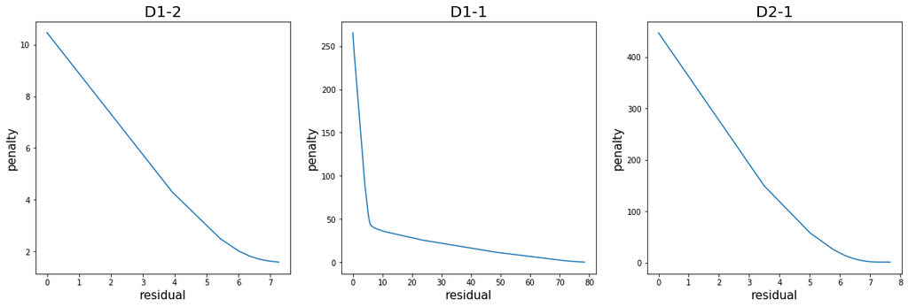

```python
_, axes = plt.subplots(1, 3, figsize=(20, 6))

axes[0].plot(res_d1_2, penalty_d1_2)
axes[0].set_title('D1-2',size=20)
axes[0].set_ylabel('penalty',size=15)
axes[0].set_xlabel('residual',size=15)

axes[1].plot(res_d1_1, penalty_d1_1)
axes[1].set_title('D1-1',size=20)
axes[1].set_ylabel('penalty',size=15)
axes[1].set_xlabel('residual',size=15)

axes[2].plot(res_d2_1, penalty_d2_1)
axes[2].set_title('D2-1',size=20)
axes[2].set_ylabel('penalty',size=15)
axes[2].set_xlabel('residual',size=15)
plt.show()
```

**Comment:** We can see that for each signal and penalty there is a point after which penalty is constant while residual is growing. We need to get a point where both the residual and penalty are minimized, the point of inflection is the point of minimum sum of them, so the best gamma is there for each case.

# Problem 2

From $$ \epsilon=\{x: (x-c)^T P^{-1} (x-c) \leq 1\} $$

we can get $$\Rightarrow$$

$$ \epsilon=\{x : 1 - (x-c)^T P^{-1} (x-c) \geq 0\} $$

which is Schur-comlement of P for matrix $\begin{pmatrix}1 & (x - c)^T\\(x - c) & P\end{pmatrix}$

Finally we put $a$ in it and get Linear Matrix Inequality:

$$ \begin{pmatrix} 1 & (a-c)^T\\ a-c & P \end{pmatrix} \succeq 0 $$

# Problem 3

```python
import scipy.linalg
from scipy.sparse import csgraph
```

```python
n = 20

adjacency_matrix = np.random.randint(0,10, size=(n,n))
adjacency_matrix = np.triu(adjacency_matrix, k=1)
adjacency_matrix += adjacency_matrix.T
np.fill_diagonal(adjacency_matrix, 0)

laplacian = csgraph.laplacian(adjacency_matrix)
```

```python
laplacian.shape
```

```
(20, 20)
```

### 1. Naive randomization.

```python
function_value = np.zeros(1000)
for i, _ in enumerate(function_value):
    cut = np.random.randint(0,2, size=laplacian.shape[0])
    cut[cut==0] = -1
    function_value[i] = cut.T @ laplacian @ cut
```

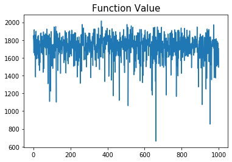

```python
plt.figure()
plt.title('Function Value',size=15)
plt.plot(function_value)
plt.show()
```

```python
print('Maximum value:',max(function_value))
```

```
Maximum value: 2016.0
```

### 2. SDP relaxatoin

```python
X = cp.Variable((n,n), symmetric=True)

c = [X >> 0]
c += [X[i, i] == 1 for i in range(n)]

problem = cp.Problem(cp.Maximize(cp.trace(laplacian @ X)),c)
problem.solve()
```

```
2135.464909049131
```

```python
print("The optimal value:", problem.value)
```

```
The optimal value: 2135.464909049131
```

We can see it is already higher than the maximum value in Naive Randomization.

### 3. Goemans-Williamson approximation.

```python
cholesky = np.linalg.cholesky(X.value + np.identity(n)*1e-1)

gw_value = np.zeros(1000)
for i in range(gw_value.shape[0]):
    cut = np.random.normal(size=n)
    cut_chol = cholesky @ cut
    cut_chol[cut_chol>0] = 1
    cut_chol[cut_chol<=0] = -1
    gw_value[i] = cut_chol.T @ laplacian @ cut_chol
```

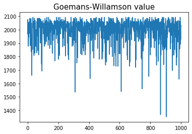

```python
plt.figure()
plt.title('Goemans-Willamson value',size=15)
plt.plot(gw_value)
plt.show()
```

```python
print('Maximum Goemans-Willamson value:',max(gw_value))
```

```
Maximum Goemans-Willamson value: 2092.0
```

### 4. Mathematical expectation

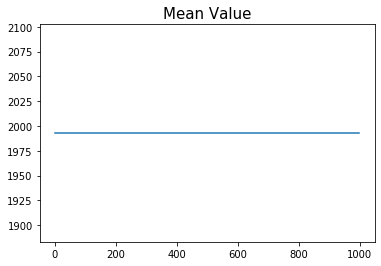

```python
mean_value = np.mean(gw_value)
plt.plot([mean_value]*1000)
plt.title('Mean Value',size=15)
plt.show()
```

# Problem 4

### 1. Formulate the above problem as a linear program

Let $x_{ij}$ be the tonns of cargo, where the raw index $i=1,2,3,4$ for $C1,C2,C3,C4$ and column index $j$ - compartment, $j=1$ - Front, $j=2$ - Centre, $j=3$ - Rear.

**The constaints of the problem are:**

- limited cargo:

$$x_{11}+x_{12}+x_{13}<=18 $$$$x_{21}+x_{22}+x_{23}<=15$$$$x_{31}+x_{32}+x_{33}<=23$$$$x_{41}+x_{42}+x_{43}<=12$$

- maximum weight capacity of every compartment:

$$x_{11}+x_{21}+x_{31}+x_{41}<=10$$$$x_{12}+x_{22}+x_{32}+x_{42}<=16$$$$x_{13}+x_{23}+x_{33}+x_{43}<=8$$

- maximum space capacity of every compartment:

$$480 x_{11}+650 x_{21}+580 x_{31}+390 x_{41}<=6800$$$$480 x_{12}+650 x_{22}+580 x_{32}+390 x_{42}<=8700$$$$480 x_{13}+650 x_{23}+580 x_{33}+390 x_{43}<=5300$$

- plane balance:

$$\frac{{x}_{11}+{x}_{21}+{x}_{31}+{x}_{41}}{10}=\frac{{x}_{12}+{x}_{22}+{x}_{32}+{x}_{42}}{16}=\frac{{x}_{13}+{x}_{23}+{x}_{33}+{x}_{43}}{8}$$

**The objective function:**

We need to maximize total profit:

$$ \text{ max } 310\left[{x}_{11}+{x}_{12}+ {x}_{13}\right]+380\left[{x}_{21}+ {x}_{22}+ {x}_{23}\right]+350\left[ {x}_{31}+ {x}_{32}+ {x}_{33}\right]+285\left[ {x}_{41}+ {x}_{42}+ {x}_{43}\right] $$

### 2. What assumptions are made in formulating this problem as a linear program?

- The data is accurate
- We are told we can split the cargoes into any fractions that we want and between any compartments
- Any cargo can be packed into any compartment

### 3. Solve the problem

```python
from scipy.optimize import linprog

A = np.array([[1,1,1,0,0,0,0,0,0,0,0,0],[0,0,0,1,1,1,0,0,0,0,0,0],
             [0,0,0,0,0,0,1,1,1,0,0,0],[0,0,0,0,0,0,0,0,0,1,1,1],
             [1,0,0,1,0,0,1,0,0,1,0,0],[0,1,0,0,1,0,0,1,0,0,1,0],
             [0,0,1,0,0,1,0,0,1,0,0,1],[480,0,0,650,0,0,580,0,0,390,0,0],
             [0,480,0,0,650,0,0,580,0,0,390,0],[0,0,480,0,0,650,0,0,580,0,0,390]])

b = np.array([18,15,23,12,10,16,8,6800,8700,5300])

# objective coeficients
c = np.array([-310,-310,-310,-380,-380,-380,-350,-350,-350,-285,-285,-285])
```

```python
result = linprog(c,A_ub=A,b_ub=b)
```

```python
print('Maximum profit:',-result.fun)
```

```
Maximum profit: 12151.578947310769
```

```python
x = result.x
print("Values of x:",x)
```

```
Values of x: [1.93275811e-11 1.43243951e-10 1.43885777e-11 9.13177720e+00
 6.11530624e-12 5.86822280e+00 8.68222802e-01 1.29473684e+01
 2.13177720e+00 1.92903489e-11 3.05263158e+00 9.13497145e-12]
```

### Lets check the last nonlinear plane balance:

$$\frac{{x}_{11}+{x}_{21}+{x}_{31}+{x}_{41}}{10}=\frac{{x}_{12}+{x}_{22}+{x}_{32}+{x}_{42}}{16}=\frac{{x}_{13}+{x}_{23}+{x}_{33}+{x}_{43}}{8}$$

```python
x = result.x
(x[0]+x[3]+x[6]+x[9])/10
```

```
0.9999999999963706
```

```python
(x[1]+x[4]+x[7]+x[10])/16
```

```
0.9999999999948345
```

```python
(x[2]+x[5]+x[8]+x[11])/8
```

```
0.9999999999968482
```

**Plane balance is working**

## Maximum profit we obtained is 12151

### 4. Sensitivity to the constraint values.

Lets change by 10% wights of cargoes and check the profit.

## C1

```python
b = np.array([20,15,23,12,10,16,8,6800,8700,5300])

result = linprog(c,A_ub=A,b_ub=b)
print('C1 weight from 18 to 20:')
print('Maximum profit:',-result.fun)
```

```
C1 weight from 18 to 20:
Maximum profit: 12151.57894729608
```

```python
b = np.array([16,15,23,12,10,16,8,6800,8700,5300])

result = linprog(c,A_ub=A,b_ub=b)
print('C1 weight from 18 to 16:')
print('Maximum profit:',-result.fun)
```

```
C1 weight from 18 to 16:
Maximum profit: 12151.578944061968
```

## C2

```python
b = np.array([18,17,23,12,10,16,8,6800,8700,5300])

result = linprog(c,A_ub=A,b_ub=b)
print('C2 weight from 15 to 17:')
print('Maximum profit:',-result.fun)
```

```
C2 weight from 15 to 17:
Maximum profit: 12211.57894569172
```

```python
b = np.array([18,13,23,12,10,16,8,6800,8700,5300])

result = linprog(c,A_ub=A,b_ub=b)
print('C2 weight from 15 to 13:')
print('Maximum profit:',-result.fun)
```

```
C2 weight from 15 to 13:
Maximum profit: 12091.578927351811
```

## C3

```python
b = np.array([18,15,26,12,10,16,8,6800,8700,5300])

result = linprog(c,A_ub=A,b_ub=b)
print('C3 weight from 23 to 26:')
print('Maximum profit:',-result.fun)
```

```
C3 weight from 23 to 26:
Maximum profit: 12151.578947315555
```

```python
b = np.array([18,15,20,12,10,16,8,6800,8700,5300])

result = linprog(c,A_ub=A,b_ub=b)
print('C3 weight from 23 to 20:')
print('Maximum profit:',-result.fun)
```

```
C3 weight from 23 to 20:
Maximum profit: 12151.578944072511
```

## C4

```python
b = np.array([18,15,23,14,10,16,8,6800,8700,5300])

result = linprog(c,A_ub=A,b_ub=b)
print('C4 weight from 12 to 14:')
print('Maximum profit:',-result.fun)
```

```
C4 weight from 12 to 14:
Maximum profit: 12151.578947105694
```

```python
b = np.array([18,15,23,10,10,16,8,6800,8700,5300])

result = linprog(c,A_ub=A,b_ub=b)
print('C3 weight from 12 to 10:')
print('Maximum profit:',-result.fun)
```

```
C3 weight from 12 to 10:
Maximum profit: 12151.57894733211
```

```python
np.round(result.x)
```

```
array([ 0.,  0.,  0.,  9.,  0.,  6.,  1., 13.,  2.,  0.,  3.,  0.])
```

**Comment:**

We can see that only the weight change of C2 affected the maximum profit, when we increase the weight by 10%, the profit is bigger (12211), while we decrease by 10%, the profit is lower (12091).